# Leading Apps on Google Play Market

Petar Randjelovic

2022-05-10

# Top Apps on Google Play Market

## Introduction

In this document we will focus on most popular Apps on the Google Play store for android devices. Why are they downloaded the most and to which category do these apps belog to?

Research done on this topic is mostly helped by the open source datasets on the internet and the availability of data on such matters.

All of the data used in this topic can be found in the **Reference** section.

## Currently the most Popular

Applications that save users time and money are the most popular because users find that they would be lost without the assistance the app is providing. When a user is able to see the value in an application and is thankful that they are able to incorporate it, then the app will be successful.

Although many apps that are at a current top of the list on Google Play Store are developed by different developers, many of them are developed by Google:

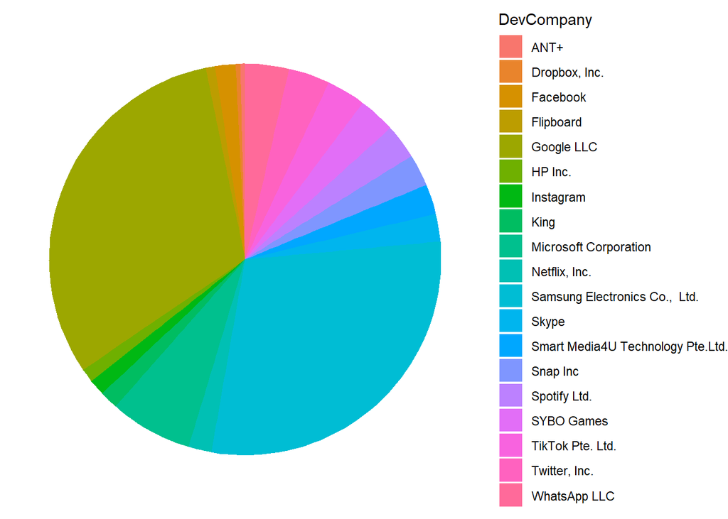

# Reason Behind the popularity

## What affects the position of the app on the App Store and Google Play?

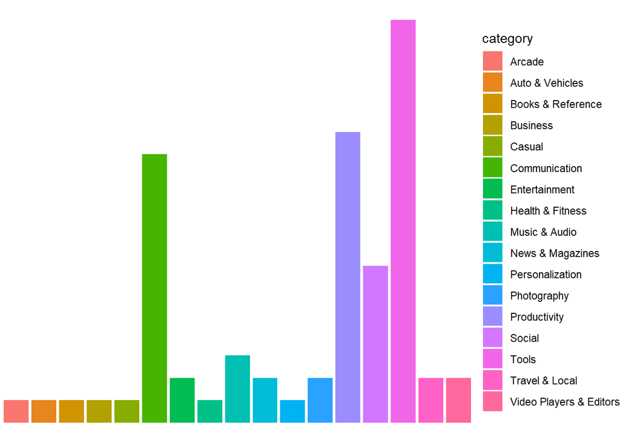

### 1. Title

As far as apps’ titles are concerned, Google Play and App Store allow 30 characters, both index them. These are the most important metadata and of prime importance to a search algorithm.

### 2. Subtitle

- There are no subtitles in *Google Play*, but App Store has got them
- on the app’s page and its search card. Up to 30 characters are allowed;
- latest research shows that subtitles are less indexed but still visible
- they have more influence on rankings than the keyword field.

### 3. Keyword field

Only App Store features a keyword field. It can accommodate up to 100 characters, counting commas between words, and the contents are indexed.

### 4. Promo text / Short description

The promo text a. k. a. short description can fit 80 characters in Google Play, this text is indexed. App Store’s holds up to 170 characters, but the contents are not indexed, on the other hand, it can be changed any time, without commitment to an update. You might, for example, announce a 50% discount for today’s special event. In App Store only the promo text among all the metadata may be changed outside of an update. In Google Play you can rewrite all of them any time.

### 5. Description

The maximum size of a description is 4000 characters in App Store and Google Play alike, but Google’s are indexed. Also Google Play tolerates emoji there and html formatting. These features help users hone in on the app. Artyom Tkaczuk covered composing descriptions for Google Play in the previous article of this series.

### 6. Reviews and relevance

Reviews are also not indexed in App Store, and indexed in Google Play. For this reason, keywords can be entered directly into reviews for some extra indexing, just not in every sentence – users should be able to get to the meaning. This was another topic for Artyom Tkaczuk in his piece.

Micro transactions (In-App Purchases) and Ad-based apps also make a difference in relevancy.

$$\dfrac{Part}{Whole(71)} \ =
\dfrac{Percentage}{100}$$

We will use a simple percentage equation to get stats on different variables determining success on the App market.

```
## [1] "Percentage of apps without ads 71.83%"
```

```
## [1] "Percentage of apps with ads 26.76%"
```

```
## [1] "Percentage of apps without microtransanctions 77.46%"
```

```
## [1] "Percentage of apps with microtransactions 21.13%"
```

### 7. Extra localizations

Only App Store has main and extra localizations for a country. This means that users will get to see different pages of the app with different metadata, appropriate for his device’s language settings, and developers can count on App Store search engine’s grabbing indexed data from those additional localizations.

This table shows what localizations may be added to increase the quantity of available keywords:

[figure not shown]

### 8. No. of search screenshots

Google Play has something called cluster searching, which means that several blocks with Google-recommended software will be interposed between the first and second app. Only cluster results display app screenshots. Screenshots are presented in a uniform manner in App Store: always three portrait screenshots or one landscape screenshot or one video and two screenshots.

### 9. Search Results

In Google Play a search produces different results pages depending on the query. Typing in something specific like “traffic tickets pay download” or a brand name like “Uber” will cause the relevant app with the highest number of downloads to appear on the top in a large card (for cluster results). The algorithm must be certain that the app does the best job at meeting users’ needs and solving their problems. For more general queries like “plane tickets” results will be more familiar: different apps listed, internal purchases for them, developer pages, Apple Search Ads, bundles, editorial pieces in a roster. I wrote about the importance of editorials in my last article.

### 10. Attributes of in-built purchases

Up to 20 in-built purchases (subscription, services, new game levels etc.) may be added to an App Store search, and each has a title, an icon and a description. In-built purchases make apps take up more screen space, which may improve conversion. Google Play does not have an equivalent feature.

*Ranking determinants that really determine*

| Factor | Google Play | App Store |
| --- | --- | --- |
| General install | Applies | Applies |
| Revenue | Applies | Applies |
| Number of Sessions | Applies | Applies |
| Sessions frequency | Applies | Does not apply |
| Number of reviews | Applies | Applies |
| Rating | Applies | Applies |
| Search query Installs | Applies | Applies |
| Recently updated | Does not apply | Applies |
| App Uninstallation | Applies | Does not apply |

# Refrences

- [Datasets Used](https://www.kaggle.com/datasets/alexandrparkhomenko/top-apps-in-google-play?resource=download)
- [Article by ASODESK](https://asodesk.com/blog/what-determines-an-apps-position-in-app-store-and-google-play/)
- [What Makes Apps Successful](https://theappsolutions.com/blog/marketing/make-apps-popular/)